# Parlamentares e o Engajamento Gerado no Twitter

Matheus Alves dos Santos

25 de junho de 2019

Na maioria dos países democráticos, os parlamentares costumam adotar perfis em redes sociais como canais de comunicação não-oficiais, através dos quais podem não somente divulgar sua atuação política, mas também comentar assuntos cotidianos e entrar em contato direto com a população em geral.

O Twitter tem atraído bastante a atenção dos brasileiros nos últimos meses e, muitas vezes, isso não se deve às suas funcionalidades, mas às polêmicas geradas a partir de postagens de figuras políticas do país. Nesse sentido, decidiu-se explorar os dados de nossos parlamentares *twitteiros* na tentativa de compreender os fatores que geram tamanho engajamento do público.

## Preparação do Ambiente

Para as análises apresentadas a seguir, foram utilizadas as bibliotecas **tidyverse**, **ggplot2**, **ggbeeswarm**, **gridExtra**, **modelr** e **broom**. Já os dados utilizados estão estruturados da seguinte maneira:

```r
congress_tt_data <- read_csv(here::here("data/twitter-activity-20190322.csv"))

congress_tt_data <- congress_tt_data %>%
  na.omit(.) %>%
  filter(partido != "S/ Partido") %>%
  filter(seguidores > 0, n_proprio > 0, n_retweet > 0)  %>%
  filter(engaj_total > 0, engaj_mediano > 0)

congress_tt_data <- congress_tt_data %>%
  mutate(casa = if_else(casa == "senado", "Senado", "Câmara"))

congress_tt_data
```

| id_parlamentar | casa | nome_eleitoral | partido | UF | twitter | seguidores | segue | n_proprio | n_retweet | engaj_total | engaj_total_proprio | engaj_total_retweet | engaj_mediano | engaj_mediano_proprio | engaj_mediano_retweet | engaj_max | engaj_max_proprio | engaj_max_retweet |
| --- | --- | --- | --- | --- | --- | --- | --- | --- | --- | --- | --- | --- | --- | --- | --- | --- | --- | --- |
| 204528 | Câmara | ADRIANA VENTURA | NOVO | SP | adrianasounovo | 4652 | 315 | 99 | 9 | 7090 | 6701 | 389 | 26.5 | 22.5 | 0.0 | 1031 | 1031 | 99 |
| 178836 | Câmara | ALAN RICK | DEM | AC | Alan_Rick | 3983 | 995 | 49 | 1 | 4286 | 284 | 4002 | 4.0 | 4.0 | 0.0 | 4002 | 38 | 4002 |
| 160559 | Câmara | ALCEU MOREIRA | MDB | RS | Alceu_Moreira | 6370 | 434 | 214 | 30 | 6852 | 2239 | 4613 | 8.0 | 8.0 | 0.0 | 4227 | 136 | 4227 |
| 204545 | Câmara | ALÊ SILVA | PSL | MG | oficialalesilva | 464 | 267 | 39 | 4 | 10231 | 186 | 10045 | 4.0 | 4.0 | 0.0 | 8171 | 14 | 8171 |
| 204501 | Câmara | ALENCAR SANTANA BRAGA | PT | SP | AlencarBraga13 | 6447 | 3253 | 346 | 100 | 69348 | 47967 | 21381 | 16.5 | 12.0 | 0.0 | 12335 | 12335 | 8623 |
| 204544 | Câmara | ALEXANDRE FROTA | PSL | SP | alefrotabrasil | 161745 | 2015 | 830 | 169 | 566011 | 320063 | 245948 | 134.0 | 60.0 | 0.0 | 20348 | 7271 | 20348 |
| 204503 | Câmara | ALEXANDRE PADILHA | PT | SP | padilhando | 147085 | 1035 | 485 | 204 | 112251 | 89409 | 22842 | 49.0 | 27.0 | 0.0 | 3643 | 3643 | 3302 |
| 178833 | Câmara | ALEXANDRE SERFIOTIS | PSD | RJ | AleSerfiotis | 880 | 41 | 1 | 1 | 2 | 1 | 1 | 1.0 | 0.5 | 0.5 | 1 | 1 | 1 |
| 204516 | Câmara | ALEXIS FONTEYNE | NOVO | SP | AlexisFonteyne | 6417 | 384 | 201 | 95 | 39439 | 29860 | 9579 | 67.0 | 22.0 | 0.0 | 1834 | 1834 | 1575 |
| 74057 | Câmara | ALICE PORTUGAL | PCdoB | BA | Alice_Portugal | 17686 | 2207 | 290 | 45 | 88433 | 9732 | 78701 | 12.0 | 8.0 | 0.0 | 27800 | 976 | 27800 |

[output cut: 280 more lines]

## Relações entre Variáveis

Antes de analisar a associação entre as características da atuação dos parlamentares no Twitter e o engajamento (total e mediano) por eles gerado, é necessário avaliar a existência de relações lineares. Como será utilizada a regressão linear múltipla, pode ser necessário transformar algumas das variáveis para que exista esse tipo de relação.

Nesse sentido, abaixo são exibidos alguns gráficos que permitem visualizar as relações entre as variáveis independentes e a variável dependente, estejam elas em seu formato original ou transformado.

### Casa do Congresso

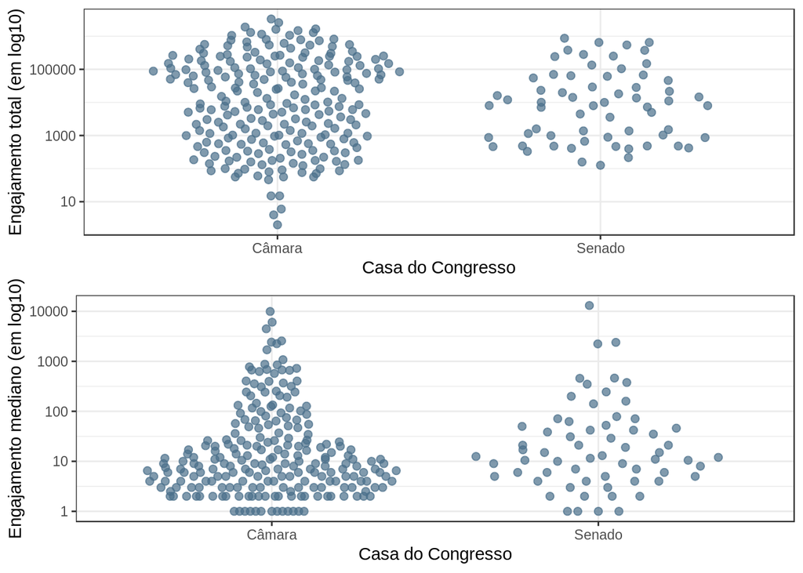

```r
total_engag_house <- congress_tt_data %>%
  ggplot(aes(x = casa, y = engaj_total)) +
  geom_quasirandom(size = 2, alpha = .7, color = "skyblue4") +
  labs(x = "Casa do Congresso", y = "Engajamento total (em log10)") +
  scale_y_log10()

median_engag_house <- congress_tt_data %>%
  ggplot(aes(x = casa, y = engaj_mediano)) +
  geom_quasirandom(size = 2, alpha = .7, color = "skyblue4") +
  labs(x = "Casa do Congresso", y = "Engajamento mediano (em log10)") +
  scale_y_log10()

grid.arrange(total_engag_house, median_engag_house, ncol = 1)
```

### Número de Perfis Seguidos

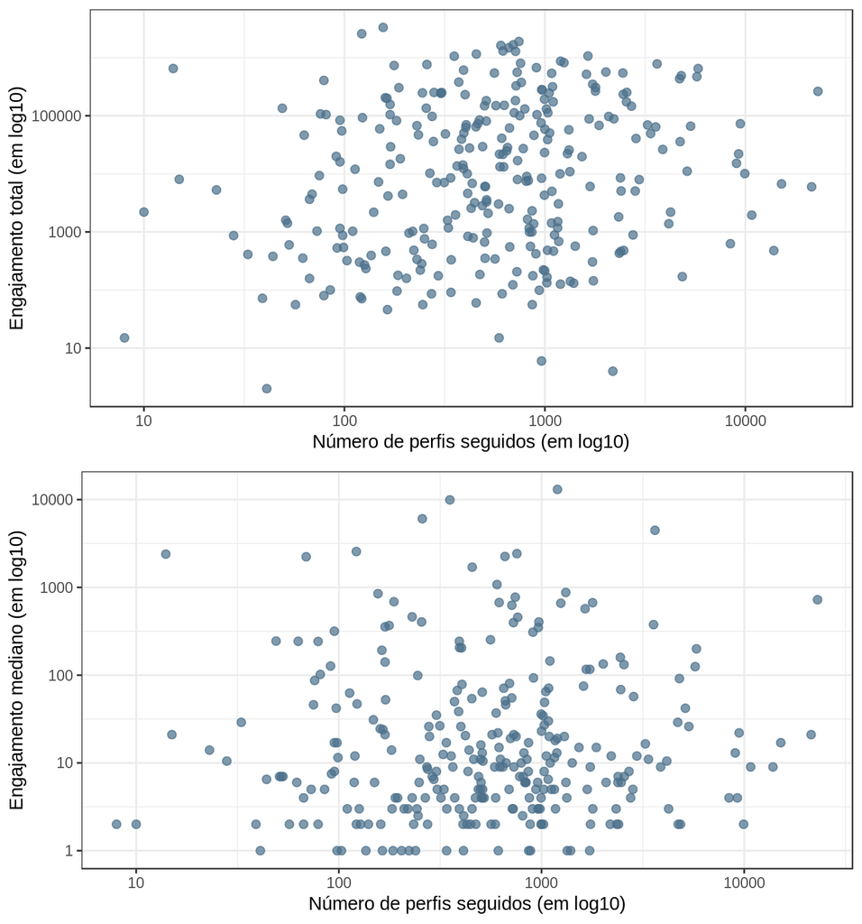

```r
total_engag_following <- congress_tt_data %>%
  ggplot(aes(x = segue, y = engaj_total)) +
  geom_point(size = 2, alpha = .7, color = "skyblue4") +
  labs(x = "Número de perfis seguidos (em log10)", y = "Engajamento total (em log10)") +
  scale_x_log10() +
  scale_y_log10()

median_engag_following <- congress_tt_data %>%
  ggplot(aes(x = segue, y = engaj_mediano)) +
  geom_point(size = 2, alpha = .7, color = "skyblue4") +
  labs(x = "Número de perfis seguidos (em log10)", y = "Engajamento mediano (em log10)") +
  scale_x_log10() +
  scale_y_log10()

grid.arrange(total_engag_following, median_engag_following, ncol = 1)
```

### Número de Seguidores

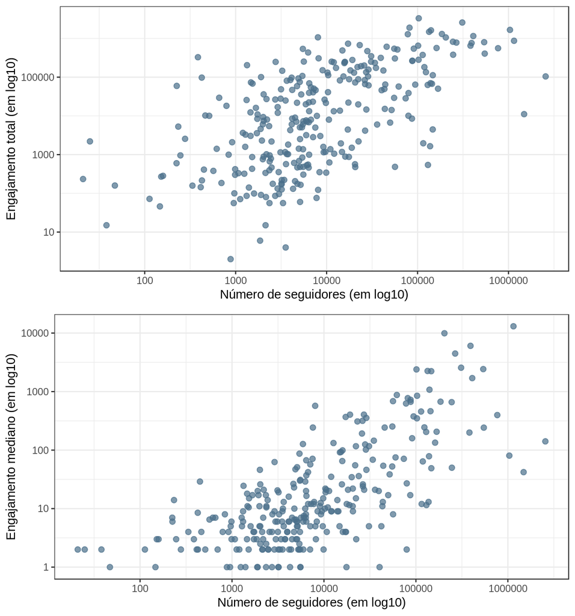

```r
total_engag_followers <- congress_tt_data %>%
  ggplot(aes(x = seguidores, y = engaj_total)) +
  geom_point(size = 2, alpha = .7, color = "skyblue4") +
  labs(x = "Número de seguidores (em log10)", y = "Engajamento total (em log10)") +
  scale_x_log10() +
  scale_y_log10()

median_engag_followers <- congress_tt_data %>%
  ggplot(aes(x = seguidores, y = engaj_mediano)) +
  geom_point(size = 2, alpha = .7, color = "skyblue4") +
  labs(x = "Número de seguidores (em log10)", y = "Engajamento mediano (em log10)") +
  scale_x_log10() +
  scale_y_log10()

grid.arrange(total_engag_followers, median_engag_followers, ncol = 1)
```

### Número de *Tweets*

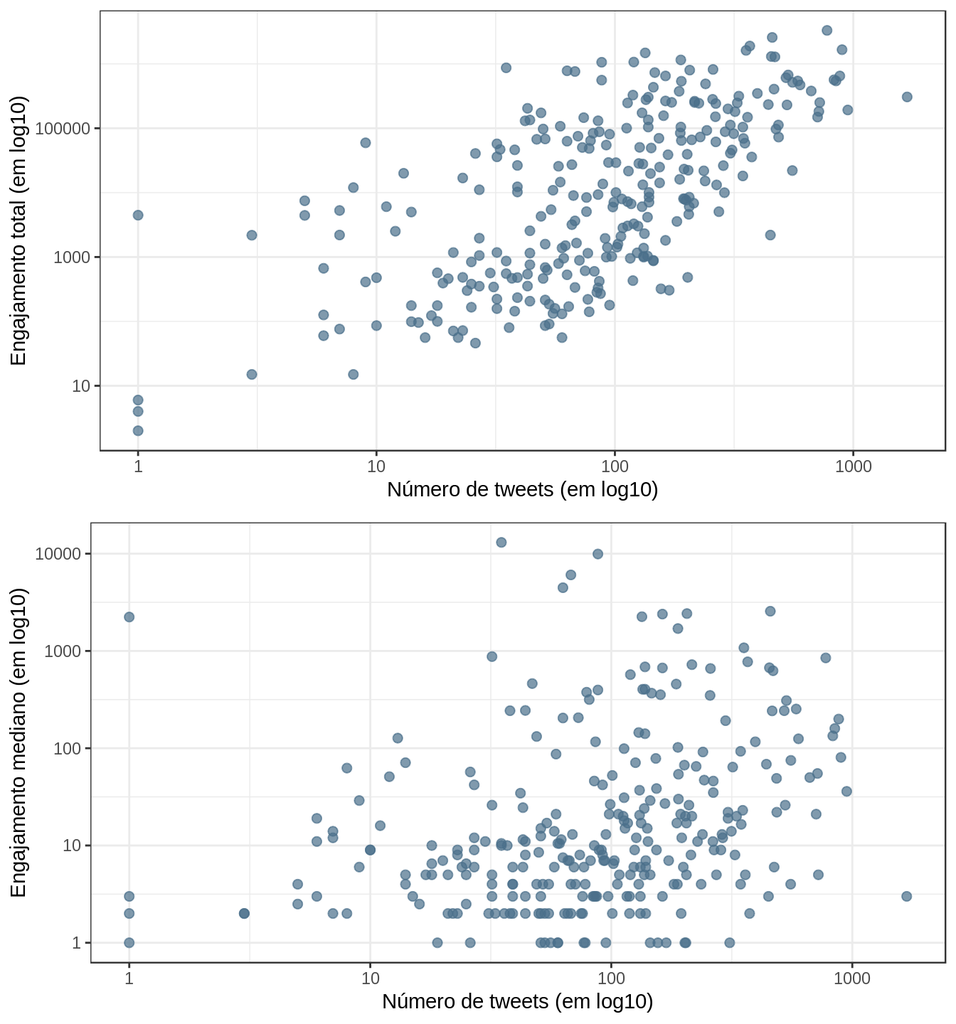

```r
total_engag_tweets <- congress_tt_data %>%
  ggplot(aes(x = n_proprio, y = engaj_total)) +
  geom_point(size = 2, alpha = .7, color = "skyblue4") +
  labs(x = "Número de tweets (em log10)", y = "Engajamento total (em log10)") +
  scale_x_log10() +
  scale_y_log10()

median_engag_tweets <- congress_tt_data %>%
  ggplot(aes(x = n_proprio, y = engaj_mediano)) +
  geom_point(size = 2, alpha = .7, color = "skyblue4") +
  labs(x = "Número de tweets (em log10)", y = "Engajamento mediano (em log10)") +
  scale_x_log10() +
  scale_y_log10()

grid.arrange(total_engag_tweets, median_engag_tweets, ncol = 1)
```

### Número de *Retweets*

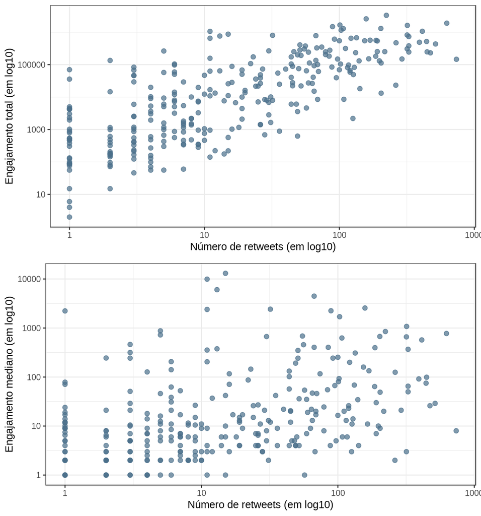

```r
total_engag_retweets <- congress_tt_data %>%
  ggplot(aes(x = n_retweet, y = engaj_total)) +
  geom_point(size = 2, alpha = .7, color = "skyblue4") +
  labs(x = "Número de retweets (em log10)", y = "Engajamento total (em log10)") +
  scale_x_log10() +
  scale_y_log10()

median_engag_retweets <- congress_tt_data %>%
  ggplot(aes(x = n_retweet, y = engaj_mediano)) +
  geom_point(size = 2, alpha = .7, color = "skyblue4") +
  labs(x = "Número de retweets (em log10)", y = "Engajamento mediano (em log10)") +
  scale_x_log10() +
  scale_y_log10()

grid.arrange(total_engag_retweets, median_engag_retweets, ncol = 1)
```

## Análises

É perceptível que, em todos os casos, foi necessário realizar transformações com base em escalas logarítmicas para que existissem relações lineares entre as variáveis dependentes e as independentes estudadas. No entanto, essa necessidade não chega a ser surpreendente, visto que são raros os casos em que variáveis do mundo real se relacionam de maneira linear. A seguir, estão apresentadas as análises de interesse com base em regressão linear múltipla utilizando as variáveis já transformadas.

```r
congress_tt_data <- congress_tt_data %>%
  mutate(segue_log = log10(segue),
         seguidores_log = log10(seguidores),
         n_proprio_log = log10(n_proprio),
         n_retweet_log = log10(n_retweet),
         engaj_total_log = log10(engaj_total),
         engaj_mediano_log = log10(engaj_mediano))
```

### 1 — Qual a relação entre as características da atuação do parlamentar e o engajamento total que ele obtém no Twitter?

Inicialmente, cria-se um modelo linear em que o engajamento total é utilizado como variável dependente, enquanto as variáveis independentes são a casa do Congresso Nacional, o número de perfis seguidos, o número de seguidores, o número de *tweets* e o número de *retweets*. Vale salientar que os valores de todas as variáveis quantitativas foram transformados com a aplicação do **log10()**. A seguir, estão apresentadas algumas estatísticas encontradas para esse modelo.

```r
total_engag_lm <- lm(engaj_total_log ~ casa + segue_log + seguidores_log + n_proprio_log + n_retweet_log,
                   data = congress_tt_data)

tidy(total_engag_lm)
```

| term | estimate | std.error | statistic | p.value |
| --- | --- | --- | --- | --- |
| (Intercept) | 0.53211703 | 0.25527121 | 2.0845164 | 0.0380065920805388451908513047783 |
| casaSenado | -0.06796713 | 0.10349138 | -0.6567419 | 0.5118786766340036598066376427596 |
| segue_log | -0.29008939 | 0.07526114 | -3.8544381 | 0.0001434890994657505311829504002 |
| seguidores_log | 0.56470768 | 0.05677662 | 9.9461311 | 0.0000000000000000000341599508191 |
| n_proprio_log | 0.53023522 | 0.09927969 | 5.3408225 | 0.0000001898576802071760357552876 |
| n_retweet_log | 0.86064824 | 0.07421486 | 11.5967110 | 0.0000000000000000000000001025894 |

```r
glance(total_engag_lm)
```

| r.squared | adj.r.squared | sigma | statistic | p.value | df | logLik | AIC | BIC | deviance | df.residual |
| --- | --- | --- | --- | --- | --- | --- | --- | --- | --- | --- |
| 0.7161578 | 0.7111606 | 0.6987039 | 143.3112 | 0.000000000000000000000000000000000000000000000000000000000000000000000000001705103 | 6 | -304.4875 | 622.975 | 648.6642 | 138.6451 | 284 |

Considerando:

- **ET:** A variável que expressa o engajamento total do parlamentar no Twitter.
- **CS:** A variável *dummy* que assume valor 1 para senadores e 0 para deputados.
- **SG:** A varíável que expressa o número de perfis seguidos pelo parlamentar no Twitter.
- **SR:** A varíável que expressa o número de seguidores do parlamentar no Twitter.
- **TW:** A varíável que expressa o número de *tweets* do parlamentar.
- **RT:** A varíável que expressa o número de *retweets* do parlamentar.

Com base nos resultados da regressão linear múltipla acima, as variáveis analisadas se relacionam através de um modelo com o seguinte formato:

$\log_{10}(ET) = 0,86 \log_{10}(RT) + 0,56 \log_{10}(SR) + 0,53 \log_{10}(TW) - 0,29 \log_{10}(SG) - 0,07 CS + 0,53$

Esse modelo é capaz de explicar **71,11%** da variância da variável independente (**R² = 0,7111606**). Portanto, o número de *retweets* e o número de seguidores são as variáveis independentes com maior impacto sobre o valor do engajamento total dos parlamentares, sendo este impacto positivo em ambos os casos.

### 2 — Qual a relação entre as características da atuação do parlamentar e o engajamento mediano que ele obtém no Twitter?

```r
median_engag_lm <- lm(engaj_mediano_log ~ casa + segue_log + seguidores_log + n_proprio_log + n_retweet_log,
                     data = congress_tt_data)

tidy(median_engag_lm)
```

| term | estimate | std.error | statistic | p.value |
| --- | --- | --- | --- | --- |
| (Intercept) | -0.7867609 | 0.20770483 | -3.787880 | 0.000185470987572283307464465762492977773945312947 |
| casaSenado | -0.1044584 | 0.08420714 | -1.240493 | 0.215816766227772377506610723685298580676317214966 |
| segue_log | -0.3410067 | 0.06123723 | -5.568617 | 0.000000059513432275487239169126704035894803723750 |
| seguidores_log | 0.7438113 | 0.04619705 | 16.100840 | 0.000000000000000000000000000000000000000006864527 |
| n_proprio_log | -0.1477701 | 0.08078025 | -1.829285 | 0.068405330220189311529743747541942866519093513489 |
| n_retweet_log | 0.2813467 | 0.06038591 | 4.659146 | 0.000004886049496595298433554346168028459373999794 |

```r
glance(median_engag_lm)
```

| r.squared | adj.r.squared | sigma | statistic | p.value | df | logLik | AIC | BIC | deviance | df.residual |
| --- | --- | --- | --- | --- | --- | --- | --- | --- | --- | --- |
| 0.5728301 | 0.5653095 | 0.5685097 | 76.16818 | 0.00000000000000000000000000000000000000000000000001977974 | 6 | -244.687 | 503.374 | 529.0632 | 91.78974 | 284 |

Considerando:

- **ET:** A variável que expressa o engajamento total do parlamentar no Twitter.
- **CS:** A variável *dummy* que assume valor 1 para senadores e 0 para deputados.
- **SG:** A varíável que expressa o número de perfis seguidos pelo parlamentar no Twitter.
- **SR:** A varíável que expressa o número de seguidores do parlamentar no Twitter.
- **TW:** A varíável que expressa o número de *tweets* do parlamentar.
- **RT:** A varíável que expressa o número de *retweets* do parlamentar.

Com base nos resultados da regressão linear múltipla acima, as variáveis analisadas se relacionam através de um modelo com o seguinte formato:

$\log_{10}(EM) = 0,74 \log_{10}(SR) + 0,28 \log_{10}(RT) - 0,34 \log_{10}(SG) - 0,15 \log_{10}(TW) - 0,10 CS - 0,79$

Esse modelo é capaz de explicar **56,53%** da variância da variável independente (**R² = 0,5653095**). Portanto, o número de seguidores e o número de perfis seguidos são as variáveis independentes com maior impacto sobre o valor do engajamento mediano dos parlamentares, sendo estes impactos positivo e negativo, respectivamente.